# Camera-Trap Monitoring Report: GMU8 Leuven, Belgium

### 2025

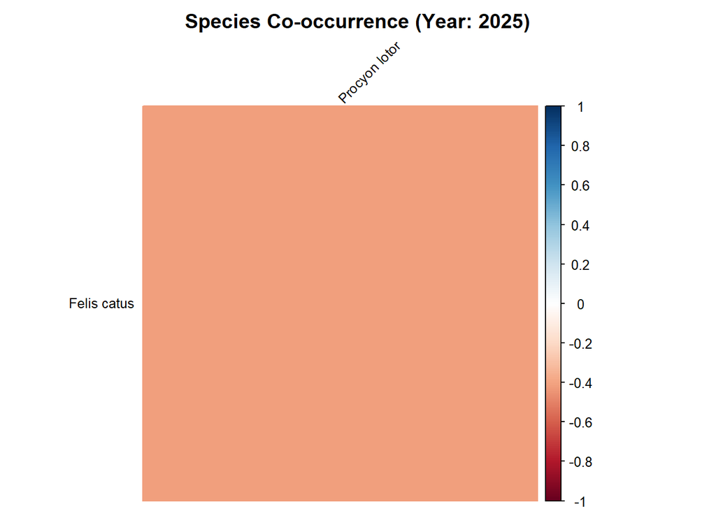

**Figure.43**: *Species co-occurrence patterns for the selected species focus group in this report, shown for survey year 2025.*

### Total

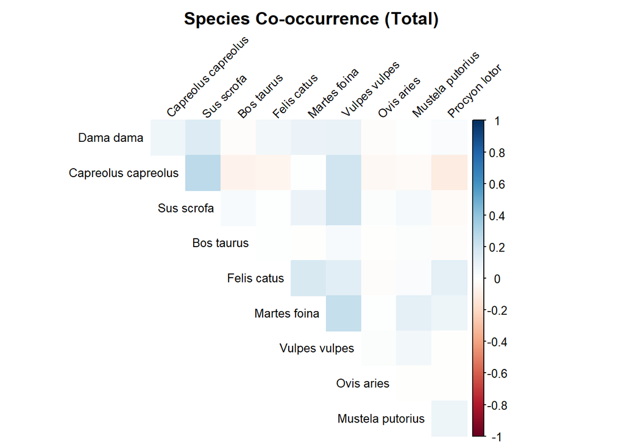

**Figure.44**: *Species co-occurrence patterns for the selected species focus group in this report, shown for the cumulative dataset across all years.*

## 3.7 Spatial Density

Spatial density maps derived from point pattern analysis illustrate the spatial distribution of species detections across the study area. These visualizations highlight variation in detection intensity and help identify areas with relatively high or low concentrations of records. The following maps are presented for each species, either by survey year or across the full monitoring period. Warmer colors represent higher estimated detection density, whereas cooler colors indicate lower density. Together, these maps support comparison of spatial detection patterns among species and across survey years.

### 2018

#### Bos taurus

[interactive chart not shown]

**Figure.45**: *Spatial point pattern density for **Bos taurus** based on the species focus group in this report, shown for survey year 2018.*

#### Capreolus capreolus

[interactive chart not shown]

**Figure.46**: *Spatial point pattern density for **Capreolus capreolus** based on the species focus group in this report, shown for survey year 2018.*

#### Felis catus

[interactive chart not shown]

**Figure.47**: *Spatial point pattern density for **Felis catus** based on the species focus group in this report, shown for survey year 2018.*

#### Martes foina

[interactive chart not shown]

**Figure.48**: *Spatial point pattern density for **Martes foina** based on the species focus group in this report, shown for survey year 2018.*

#### Mustela putorius

[interactive chart not shown]

**Figure.49**: *Spatial point pattern density for **Mustela putorius** based on the species focus group in this report, shown for survey year 2018.*

#### Sus scrofa

[interactive chart not shown]

**Figure.50**: *Spatial point pattern density for **Sus scrofa** based on the species focus group in this report, shown for survey year 2018.*

#### Vulpes vulpes

[interactive chart not shown]

**Figure.51**: *Spatial point pattern density for **Vulpes vulpes** based on the species focus group in this report, shown for survey year 2018.*

### 2019

#### Capreolus capreolus

[interactive chart not shown]

**Figure.52**: *Spatial point pattern density for **Capreolus capreolus** based on the species focus group in this report, shown for survey year 2019.*

#### Felis catus

[interactive chart not shown]

**Figure.53**: *Spatial point pattern density for **Felis catus** based on the species focus group in this report, shown for survey year 2019.*

#### Martes foina

[interactive chart not shown]

**Figure.54**: *Spatial point pattern density for **Martes foina** based on the species focus group in this report, shown for survey year 2019.*

#### Mustela putorius

[interactive chart not shown]

**Figure.55**: *Spatial point pattern density for **Mustela putorius** based on the species focus group in this report, shown for survey year 2019.*

#### Sus scrofa

[interactive chart not shown]

**Figure.56**: *Spatial point pattern density for **Sus scrofa** based on the species focus group in this report, shown for survey year 2019.*

#### Vulpes vulpes

[interactive chart not shown]

**Figure.57**: *Spatial point pattern density for **Vulpes vulpes** based on the species focus group in this report, shown for survey year 2019.*

### 2020

#### Capreolus capreolus

[interactive chart not shown]

**Figure.58**: *Spatial point pattern density for **Capreolus capreolus** based on the species focus group in this report, shown for survey year 2020.*

#### Dama dama

[interactive chart not shown]

**Figure.59**: *Spatial point pattern density for **Dama dama** based on the species focus group in this report, shown for survey year 2020.*

#### Felis catus

[interactive chart not shown]

**Figure.60**: *Spatial point pattern density for **Felis catus** based on the species focus group in this report, shown for survey year 2020.*

#### Martes foina

[interactive chart not shown]

**Figure.61**: *Spatial point pattern density for **Martes foina** based on the species focus group in this report, shown for survey year 2020.*

#### Sus scrofa

[interactive chart not shown]

**Figure.62**: *Spatial point pattern density for **Sus scrofa** based on the species focus group in this report, shown for survey year 2020.*

#### Vulpes vulpes

[interactive chart not shown]

**Figure.63**: *Spatial point pattern density for **Vulpes vulpes** based on the species focus group in this report, shown for survey year 2020.*

### 2021

#### Capreolus capreolus

[interactive chart not shown]

**Figure.64**: *Spatial point pattern density for **Capreolus capreolus** based on the species focus group in this report, shown for survey year 2021.*

#### Dama dama

[interactive chart not shown]

**Figure.65**: *Spatial point pattern density for **Dama dama** based on the species focus group in this report, shown for survey year 2021.*

#### Felis catus

[interactive chart not shown]

**Figure.66**: *Spatial point pattern density for **Felis catus** based on the species focus group in this report, shown for survey year 2021.*

#### Martes foina

[interactive chart not shown]

**Figure.67**: *Spatial point pattern density for **Martes foina** based on the species focus group in this report, shown for survey year 2021.*

#### Sus scrofa

[interactive chart not shown]

**Figure.68**: *Spatial point pattern density for **Sus scrofa** based on the species focus group in this report, shown for survey year 2021.*

#### Vulpes vulpes

[interactive chart not shown]

**Figure.69**: *Spatial point pattern density for **Vulpes vulpes** based on the species focus group in this report, shown for survey year 2021.*

### 2022

#### Bos taurus

[interactive chart not shown]

**Figure.70**: *Spatial point pattern density for **Bos taurus** based on the species focus group in this report, shown for survey year 2022.*

#### Capreolus capreolus

[interactive chart not shown]

**Figure.71**: *Spatial point pattern density for **Capreolus capreolus** based on the species focus group in this report, shown for survey year 2022.*

#### Dama dama

[interactive chart not shown]

**Figure.72**: *Spatial point pattern density for **Dama dama** based on the species focus group in this report, shown for survey year 2022.*

#### Felis catus

[interactive chart not shown]

**Figure.73**: *Spatial point pattern density for **Felis catus** based on the species focus group in this report, shown for survey year 2022.*

#### Martes foina

[interactive chart not shown]

**Figure.74**: *Spatial point pattern density for **Martes foina** based on the species focus group in this report, shown for survey year 2022.*

#### Mustela putorius

[interactive chart not shown]

**Figure.75**: *Spatial point pattern density for **Mustela putorius** based on the species focus group in this report, shown for survey year 2022.*

#### Sus scrofa

[interactive chart not shown]

**Figure.76**: *Spatial point pattern density for **Sus scrofa** based on the species focus group in this report, shown for survey year 2022.*

#### Vulpes vulpes

[interactive chart not shown]

**Figure.77**: *Spatial point pattern density for **Vulpes vulpes** based on the species focus group in this report, shown for survey year 2022.*

### 2023

#### Capreolus capreolus

[interactive chart not shown]

**Figure.78**: *Spatial point pattern density for **Capreolus capreolus** based on the species focus group in this report, shown for survey year 2023.*

#### Dama dama

[interactive chart not shown]

**Figure.79**: *Spatial point pattern density for **Dama dama** based on the species focus group in this report, shown for survey year 2023.*

#### Felis catus

[interactive chart not shown]

**Figure.80**: *Spatial point pattern density for **Felis catus** based on the species focus group in this report, shown for survey year 2023.*

#### Martes foina

[interactive chart not shown]

**Figure.81**: *Spatial point pattern density for **Martes foina** based on the species focus group in this report, shown for survey year 2023.*

#### Mustela putorius

[interactive chart not shown]

**Figure.82**: *Spatial point pattern density for **Mustela putorius** based on the species focus group in this report, shown for survey year 2023.*

#### Sus scrofa

[interactive chart not shown]

**Figure.83**: *Spatial point pattern density for **Sus scrofa** based on the species focus group in this report, shown for survey year 2023.*

#### Vulpes vulpes

[interactive chart not shown]

**Figure.84**: *Spatial point pattern density for **Vulpes vulpes** based on the species focus group in this report, shown for survey year 2023.*

### 2024

#### Capreolus capreolus

[interactive chart not shown]

**Figure.85**: *Spatial point pattern density for **Capreolus capreolus** based on the species focus group in this report, shown for survey year 2024.*

#### Dama dama

[interactive chart not shown]

**Figure.86**: *Spatial point pattern density for **Dama dama** based on the species focus group in this report, shown for survey year 2024.*

#### Felis catus

[interactive chart not shown]

**Figure.87**: *Spatial point pattern density for **Felis catus** based on the species focus group in this report, shown for survey year 2024.*

#### Martes foina

[interactive chart not shown]

**Figure.88**: *Spatial point pattern density for **Martes foina** based on the species focus group in this report, shown for survey year 2024.*

#### Mustela putorius

[interactive chart not shown]

**Figure.89**: *Spatial point pattern density for **Mustela putorius** based on the species focus group in this report, shown for survey year 2024.*

#### Procyon lotor

[interactive chart not shown]

**Figure.90**: *Spatial point pattern density for **Procyon lotor** based on the species focus group in this report, shown for survey year 2024.*

#### Sus scrofa

[interactive chart not shown]

**Figure.91**: *Spatial point pattern density for **Sus scrofa** based on the species focus group in this report, shown for survey year 2024.*

#### Vulpes vulpes

[interactive chart not shown]

**Figure.92**: *Spatial point pattern density for **Vulpes vulpes** based on the species focus group in this report, shown for survey year 2024.*

### 2025

#### Felis catus

[interactive chart not shown]

**Figure.93**: *Spatial point pattern density for **Felis catus** based on the species focus group in this report, shown for survey year 2025.*

#### Procyon lotor

[interactive chart not shown]

**Figure.94**: *Spatial point pattern density for **Procyon lotor** based on the species focus group in this report, shown for survey year 2025.*

### Total

#### Bos taurus

[interactive chart not shown]

**Figure.95**: *Spatial point pattern density for **Bos taurus** based on the species focus group in this report, shown for the cumulative dataset across all years.*

#### Capreolus capreolus

[interactive chart not shown]

**Figure.96**: *Spatial point pattern density for **Capreolus capreolus** based on the species focus group in this report, shown for the cumulative dataset across all years.*

#### Dama dama

[interactive chart not shown]

**Figure.97**: *Spatial point pattern density for **Dama dama** based on the species focus group in this report, shown for the cumulative dataset across all years.*

#### Felis catus

[interactive chart not shown]

**Figure.98**: *Spatial point pattern density for **Felis catus** based on the species focus group in this report, shown for the cumulative dataset across all years.*

#### Martes foina

[interactive chart not shown]

**Figure.99**: *Spatial point pattern density for **Martes foina** based on the species focus group in this report, shown for the cumulative dataset across all years.*

#### Mustela putorius

[interactive chart not shown]

**Figure.100**: *Spatial point pattern density for **Mustela putorius** based on the species focus group in this report, shown for the cumulative dataset across all years.*

#### Ovis aries

[interactive chart not shown]

**Figure.101**: *Spatial point pattern density for **Ovis aries** based on the species focus group in this report, shown for the cumulative dataset across all years.*

#### Procyon lotor

[interactive chart not shown]

**Figure.102**: *Spatial point pattern density for **Procyon lotor** based on the species focus group in this report, shown for the cumulative dataset across all years.*

#### Sus scrofa

[interactive chart not shown]

**Figure.103**: *Spatial point pattern density for **Sus scrofa** based on the species focus group in this report, shown for the cumulative dataset across all years.*

#### Vulpes vulpes

[interactive chart not shown]

**Figure.104**: *Spatial point pattern density for **Vulpes vulpes** based on the species focus group in this report, shown for the cumulative dataset across all years.*

## 3.8 Habitat Preferences

Habitat preferences were assessed by comparing proportional capture rates across habitat types for each species. Capture rate, expressed as detections relative to sampling effort, serves here as an indicator of habitat use and relative habitat association rather than a direct estimate of habitat selection. Differences in the distribution of capture rates among habitat types therefore highlight habitats in which species were more or less frequently recorded. Together, these patterns provide insight into species-specific habitat use within the study area and help identify broad differences in habitat association among the focal species.

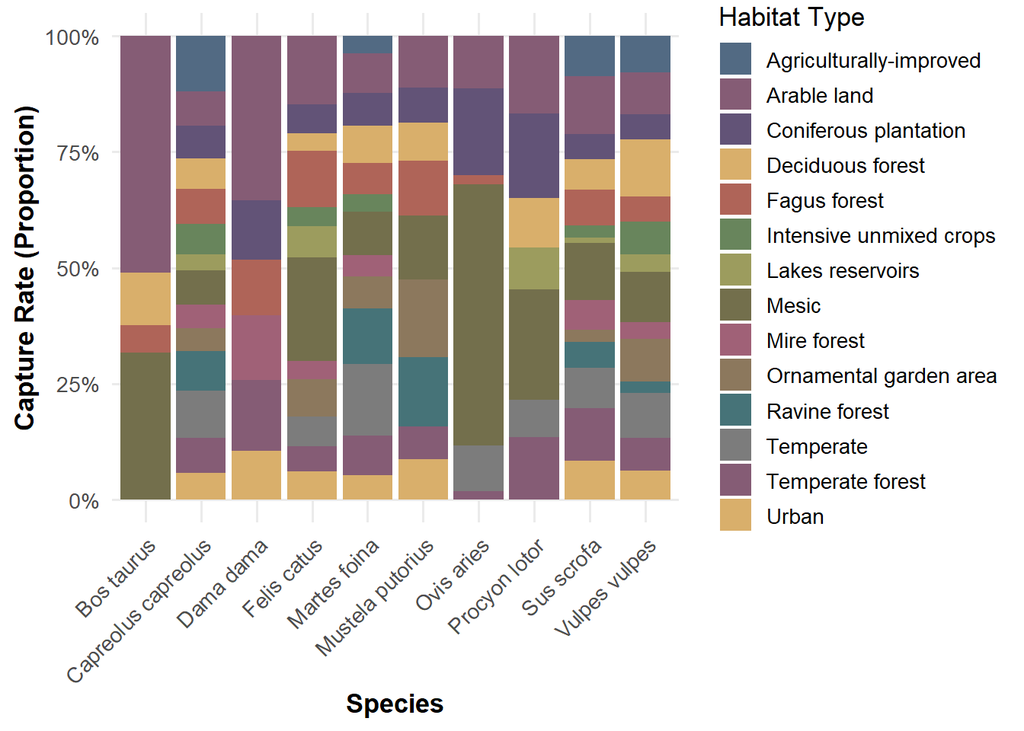

**Figure.105**: *Capture rate distribution across habitat types based on the species focus group. Each bar represents a species, with sections indicating the proportion of each habitat type.*

## 3.9 Species Accumulation Curves

Species accumulation curves show how recorded species richness changes with sampling effort, measured here as the number of camera-trap deployments. For each year available for this site, curves were derived from species presence–absence across deployments using the [iNEXT](https://cran.r-project.org/web/packages/iNEXT/index.html) R package. The tabs below show yearly curves with 95% confidence intervals, and the final Comparison tab overlays years with sufficient data.

### 2018

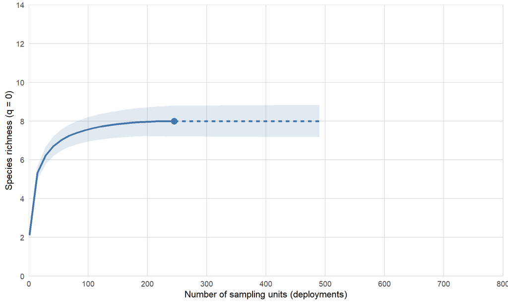

**Figure.106**: *Species accumulation curve for the focal species group in 2018, with 95% confidence interval.*

### 2019

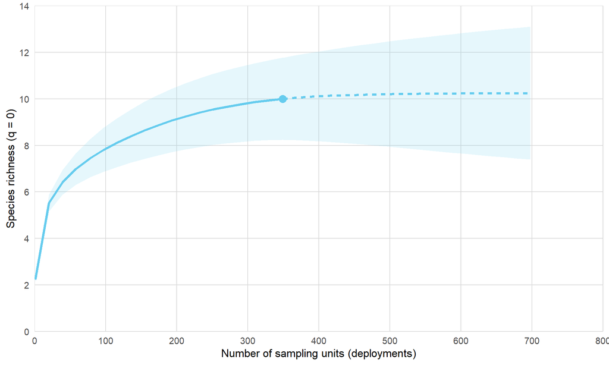

**Figure.107**: *Species accumulation curve for the focal species group in 2019, with 95% confidence interval.*

### 2020

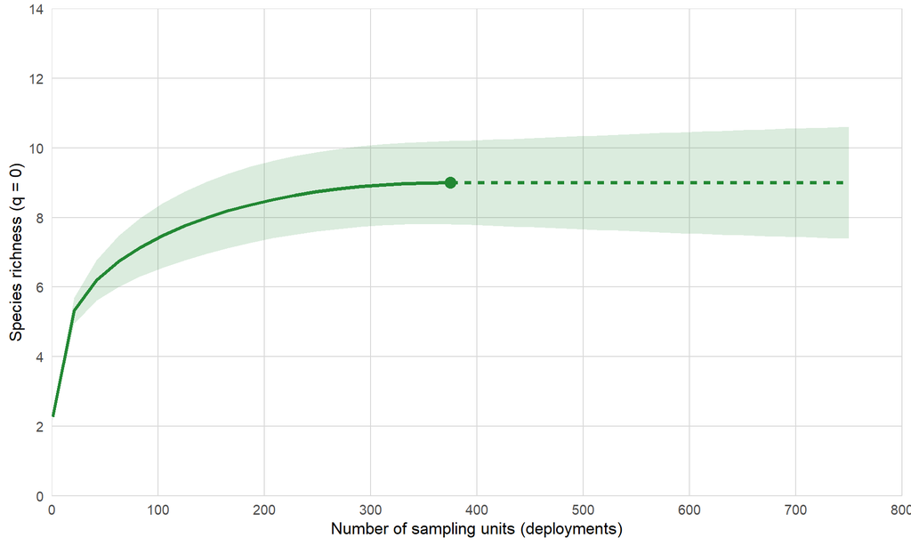

**Figure.108**: *Species accumulation curve for the focal species group in 2020, with 95% confidence interval.*

### 2021

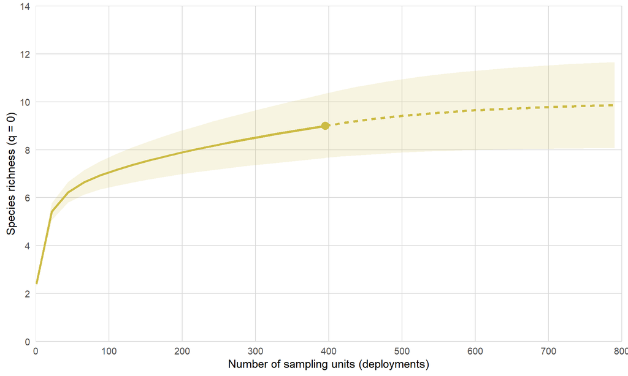

**Figure.109**: *Species accumulation curve for the focal species group in 2021, with 95% confidence interval.*

### 2022

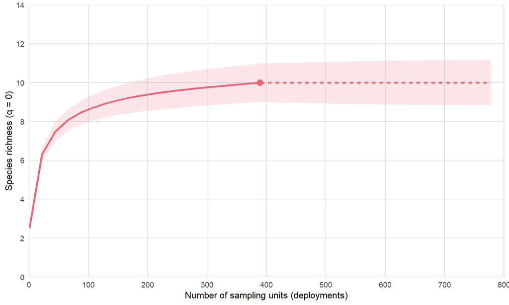

**Figure.110**: *Species accumulation curve for the focal species group in 2022, with 95% confidence interval.*

### 2023

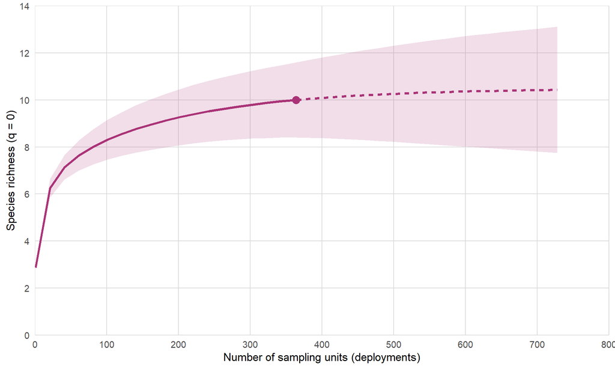

**Figure.111**: *Species accumulation curve for the focal species group in 2023, with 95% confidence interval.*

### 2024

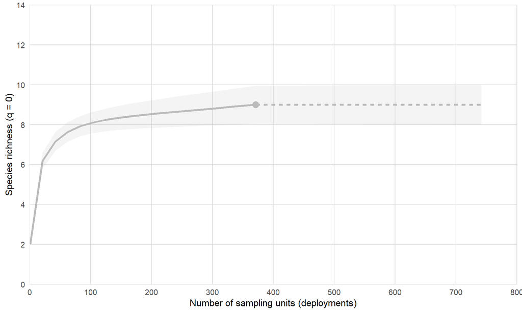

**Figure.112**: *Species accumulation curve for the focal species group in 2024, with 95% confidence interval.*

### 2025

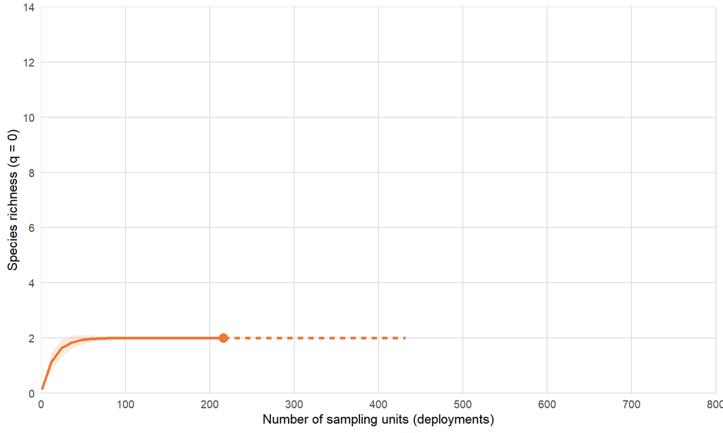

**Figure.113**: *Species accumulation curve for the focal species group in 2025, with 95% confidence interval.*

### Comparison

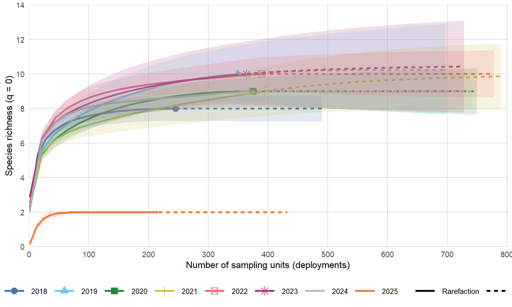

**Figure.114**: *Species accumulation curves by year for the focal species group. Solid lines indicate rarefaction, dashed lines extrapolation, and points observed sample size.*

# 4 Acknowledgements

This report was generated using the [*camtrapReport*](https://github.com/spatialecology/camtrapReport) R package, developed by Elham Ebrahimi at [Wageningen University & Research](https://www.wur.nl/en/persons/e-elham-ebrahimi) and [Utrecht University](https://www.uu.nl/staff/EEbrahimi), the Netherlands. The development of *camtrapReport* was supported by [Biodiversa+](https://www.biodiversa.eu/2022/10/07/2022-2023-joint-call/) through the [Big Picture project](https://wildlifecamera.eu/). We also gratefully acknowledge the [European Observatory of Wildlife](https://wildlifeobservatory.org/) network for its contribution to package testing. Users are kindly requested to [cite the package](https://zenodo.org/records/18405441) when using *camtrapReport* or publishing results derived from it.

# Appendix

The following images showcase a selection of 8 species: *Capreolus capreolus*, *Dama dama*, *Felis catus*, *Martes foina*, *Mustela putorius*, *Procyon lotor*, *Sus scrofa*, *Vulpes vulpes*, captured at different camera locations within this study site.

[figure not shown]

[figure not shown]

[figure not shown]

[figure not shown]

[figure not shown]

[figure not shown]

[figure not shown]

[figure not shown]

# References

- Bubnicki, J. W. et al. (2024). Camtrap DP: an open standard for the FAIR exchange and archiving of camera trap data. *Remote Sensing in Ecology and Conservation*, 10, 283–295. https://doi.org/10.1002/rse2.374
- Casaer, J. et al. (2019). Agouti: A platform for processing and archiving of camera trap images. *Biodiversity Information Science and Standards*, 3, e46690. https://doi.org/10.3897/biss.3.46690
- Coad, L. et al. (2015). Measuring impact of protected area management interventions: current and future use of the Global Database of Protected Area Management Effectiveness. *Philosophical Transactions of the Royal Society B: Biological Sciences*, 370. https://doi.org/10.1098/rstb.2014.0281
- Dirzo, R. et al. (2014). Defaunation in the Anthropocene. *Science*, 345, 401–406. https://doi.org/10.1126/science.1251817
- Gotelli, N. J. (2000). Null model analysis of species co-occurrence patterns. *Ecology*, 81, 2606–2621. https://doi.org/10.1890/0012-9658(2000)081[2606:NMAOSC]2.0.CO;2
- Kays, R. et al. (2009). Camera traps as sensor networks for monitoring animal communities. In *2009 IEEE 34th Conference on Local Computer Networks*, 811–818. https://doi.org/10.1109/LCN.2009.5355046
- Newbold, T. et al. (2015). Global effects of land use on local terrestrial biodiversity. *Nature*, 520, 45–50. https://doi.org/10.1038/nature14324
- O’Connell, A. F. et al. (2011). *Camera traps in animal ecology: methods and analyses*. Springer. https://doi.org/10.1007/978-4-431-99495-4
- Palencia, P. et al. (2022). Random encounter model is a reliable method for estimating population density of multiple species using camera traps. *Remote Sensing in Ecology and Conservation*, 8, 670–682. https://doi.org/10.1002/rse2.269
- Rowcliffe, J. M. et al. (2008). Estimating animal density using camera traps without the need for individual recognition. *Journal of Applied Ecology*, 1228–1236. https://doi.org/10.1111/2041-210X.12278
- Rowcliffe, M. & Rowcliffe, M. M. (2016). *Package ‘activity’*. Animal activity statistics R package version, 1(10.32614). https://doi.org/10.32614/CRAN.package.activity